# ฮามอนิกส์แบบมีแรงต้าน

โดย รศ.ดร.ทีปานิส ชาชิโย teepanisc@nu.ac.th  
ภาควิชาฟิสิกส์ คณะวิทยาศาสตร์ มหาวิทยาลัยนเรศวร  
วิชา คณิตศาสตร์สำหรับฟิสิกส์  
🛜 Facebook: https://web.facebook.com/teepanis.chachiyo

ในหัวข้อนี้เราจะประยุกต์ใช้แคลคูลัส เพื่อแก้สมการการเคลื่อนที่ของฟิสิกส์ และวิเคราะห์การเคลื่อนที่ของมวล $m$ ภายใต้แรงของสปริงและแรงต้านของตัวกลาง ดังแสดงในภาพ

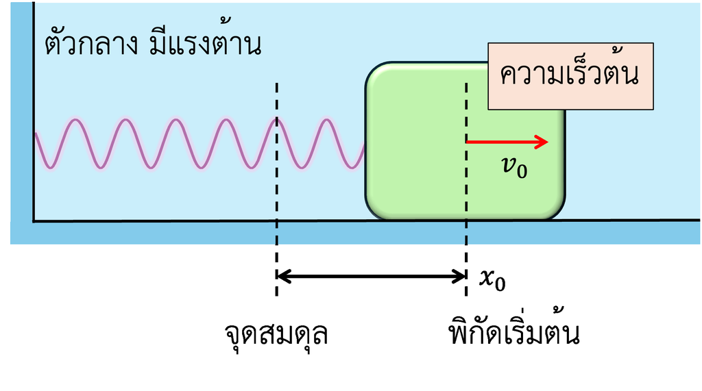

## สมการควบคุมการเคลื่อนที่

พิจารณาระบบของสปริงที่มีแรงจากกฎของ Hook: $F = - k x$, และแรงต้านเท่ากับ $F_r = - \beta \frac{dx}{dt}$ เราเขียนสมการกฎข้อสองของนิวตันได้เป็น

$$ \begin{align} \sum F & = m a \\ -kx - \beta \frac{dx}{dt} & = m \frac{d^2 x}{dt^2} \label{eq:newtonlaw} \end{align} $$

สมการ (\ref{eq:newtonlaw}) สามารถจัดรูปให้เป็นสมการอนุพันธ์มาตรฐาน Second Order Ordinary Differential Equation ได้ว่า

$$ \begin{equation} \boxed{ m \frac{d^2}{dt^2} x(t) + \beta \frac{d}{dt} x(t) + k x(t) = 0 } \label{eq:physode} \end{equation} $$

ซึ่งเราจะเทียบเคียงกับรูปแบบมาตรฐาน ที่เห็นได้ทั่วไปดังนี้

$$ \begin{equation} a y'' + b y' + c y = 0 \label{eq:mathode} \end{equation} $$

โดยเราจะแก้สมการและแจกแจงผลเฉลยของสมการ (\ref{eq:mathode}) เสียก่อน จึงจะวกลับมาเทียบเคียงกับสมการ (\ref{eq:physode}) ในทางฟิสิกส์ ในภายหลัง

## คำตอบทางคณิตศาสตร์

เพื่อหาคำตอบ $y(t)$ ของสมการ (\ref{eq:mathode}) เราจะตั้งสมมุติฐาน (Ansatz) ว่าผลเฉลย(อาจจะ)สามารถเขียนให้อยู่ในรูป

$$ \begin{equation} \text{Ansatz: } \quad y(t) = e^{rt} \label{eq:ansatz1} \end{equation} $$

ทั้งนี้หากเราสามารถทำให้สมการ (\ref{eq:mathode}) เป็นจริงได้ ด้วยสมมุติฐานข้อนี้ จึงเป็นว่า สมมุติฐานถูกต้อง และเป็นคำตอบของสมการอนุพันธ์

แทนสมมุติฐานในสมการ (\ref{eq:ansatz1}) ในสมการอนุพันธ์ (\ref{eq:mathode}) จะได้

$$ \begin{equation} a r^2 e^{r t} + b r e^{r t} + c e^{rt} = 0 \end{equation} $$

ซึ่งลดรูปเหลือเพียง

$$ \begin{equation} a r^2 + b r + c = 0 \end{equation} $$

ข้างต้นนี้เอง คือ เงื่อนไขที่จะทำให้สมมุติฐานเป็นจริง (เป็นคำตอบของสมการอนุพันธ์) คือ ค่า $r$ ไม่ใช่จะเป็นอะไรก็ได้ แต่ถูกควบคุมด้วยค่าคงที่ $a,b,c$ ที่อยู่ในสมการอนุพันธ์ตั้งแต่แรก

จากความรู้เรื่อง Quadratic Root เราบอกได้ทันทีว่า

$$ \begin{equation} r_{1,2} = \frac{-b \pm \sqrt{b^2 - 4 a c}}{2 a} \label{eq:math_roots} \end{equation} $$

กล่าวคือ มี $r$ อยู่ 2 ค่าที่จะทำให้สมการเป็นจริง นอกจากนี้ ธรรมชาติของผลเฉลยยังมีประเด็นที่ซับซ้อนมากไปกว่านั้น

1. เมื่อคูณค่าคงที่เข้าไปใน Ansatz ก็ยังเป็นคำตอบของสมการ กล่าวคือ $y(t) = C e^{r t}$ ก็ยังทำให้สมการ (\ref{eq:mathode}) เป็นจริง
2. เมื่อนำผลเฉลยของทั้ง $r_{1}$ และ $r_{2}$ มาบวกกันเข้า กล่าวคือ $y(t) = e^{r_1 t} + e^{r_2 t}$ ก็ยังทำให้สมการ (\ref{eq:mathode}) เป็นจริง เมื่อเป็นเช่นนี้ เราจะรวบรัดแต่เพียงว่า ผลเฉลยอยู่ในรูป $e^{r t}$ ไม่ได้ จำเป็นต้องเขียนให้อยู่ในรูปทั่วไปมากที่สุด ก็คือ

$$ \begin{equation} \boxed{ b^2 - 4 a c \ne 0: \qquad y(t) = C_1 e^{r_1 t} + C_2 e^{r_2 t} } \end{equation} $$

3. กรณี $b^2-4 a c = 0$ จะทำให้มีรากเพียงตัวเดียวคือ $r_{1,2} = -\frac{b}{2 a}$ แต่คำตอบที่เป็นไปได้ กลับมีรูปแบบพิเศษเพิ่มขึ้นมาอีก

เพื่อเข้าใจในประเด็นนี้ ลองแทนค่า $c = \frac{b^2}{4 a}$ ซึ่งเป็นเงื่อนไขเฉพาะในกรณีพิเศษนี้ กลับเข้าไปในสมการอนุพันธ์ (\ref{eq:mathode})

$$ \begin{equation} b^2-4 ac = 0: \qquad a y'' + b y' + \frac{b^2}{4 a} y = 0 \end{equation} $$

สมการอนุพันธ์ข้างต้น นอกจาก Ansatz $y = e^{r t}$ ที่ใช้งานได้ แล้วจะพบว่า ยังอีกกรณีหนึ่งคือ

$$ \begin{equation} \text{Ansatz:} \quad b^2-4 a c = 0, \quad y(t) = t e^{r t} \end{equation} $$

ที่ทำให้สมการเป็นจริงได้เช่นกัน เราสามารถทดสอบสมมุติฐานนี้ได้ ด้วยการแทนกลับเข้าไปในสมการอนุพันธ์

$$ \begin{equation} a \left[ t r^2 e^{r t} + 2 r e^{r t} \right] + b \left[ t r e^{rt} + e^{r t} \right] + \frac{b^2}{4 a} \left[ t e^{r t} \right] = 0 \end{equation} $$

ซึ่งเมื่อคูณ $e^{- r t}$ ตลอดสองข้างของสมการ จึงลดรูปเหลือเพียง

$$ \begin{equation} a \left[ t r^2 + 2 r \right] + b \left[ t r + 1 \right] + \frac{b^2}{4 a} \left[ t \right] = 0 \end{equation} $$

สมการข้างต้น เป็นจริงได้ เมื่อเราแทน $r = -\frac{b}{2 a}$ ดังจะเห็นได้จาก

$$ \begin{equation} a \left[ t \frac{b^2}{4 a ^2} - \frac{b}{a} \right] + b\left[ - t\frac{b}{2 a} + 1 \right] + t \frac{b^2}{4 a} = 0 \end{equation} $$

สังเกตว่าทางซ้ายมือของสมการเป็นศูนย์ ดังนั้น $0 = 0$ แปลว่าสมการเป็นจริง

โดยสรุปแล้ว กรณี $r_1 = r_2$ จึงต้องมีรูปแบบของสมการเพิ่มขึ้นมาคือ $y = t e^{r t}$ หรือ เขียนในรูปทั่วไปได้เป็น

$$ \begin{equation} \boxed{ b^2 - 4 a c = 0: \qquad y(t) = C_1 e^{r t} + C_2 t e^{r t} } \end{equation} $$

## คำตอบทางฟิสิกส์

การจะนำผลเฉลยทางคณิตศาสตร์มาประยุกต์เป็นคำตอบของฟิสิกส์สมการ (\ref{eq:physode}) มีความซับซ้อนอยู่บ้าง เพราะค่าคงที่ $C_1, C_2$ และการที่ $r_{1,2}$ มีความเป็นไปได้หลายรูปแบบ บางครั้ง อาจเป็นถึงจำนวนเชิงซ้อน ซึ่งเราจะได้แจกแจงต่อไปนี้

### เงื่อนไขเริ่มต้น

ก่อนอื่น เรากำหนดเงื่อนไขเริ่มต้นทางฟิสิกส์เสียก่อน คือ

$$ \begin{equation} \text{at } t = 0: \quad x(0) = x_0, \; v(0) = v_0 \end{equation} $$

### ผลเฉลยใน 3 กรณี

เราเปลี่ยนผลเฉลยทางคณิตศาสตร์ที่เขียนในรูป $y(t)$ และค่าคงที่ $(a,b,c)$ มาเป็นพิกัดทางฟิสิกส์ $x(t)$ และปริมาณทางฟิสิกส์ คือ มวล สัมประสิทธิ์แรงต้าน และค่านิจสปริง $(m,\beta,k)$

#### 1 กรณี $\beta^2 - 4 m k > 0$

จากสมการ (\ref{eq:math_roots}) นี้เป็นกรณีที่วิเคราะ์ง่ายที่สุด เพราะรากมีค่าเป็นจำนวนจริง จากรูปทั่วไปของผลเฉลยทางคณิตศาสตร์ เราเขียนคำตอบในทางฟิสิกส์ได้เป็น

$$ \begin{equation} x(t) = C_1 e^{r_1 t} + C_2 e^{r_2 t}, \quad r_{1,2} = \frac{-\beta \pm \sqrt{\beta^2 - 4 m k}}{2 m} \label{eq:phys_over} \end{equation} $$

ซึ่งเมื่อหาอนุพันธ์อันดับหนึ่ง $\frac{dx}{dt} = v(t)$ เพื่อเขียนเป็นความเร็ว กลายเป็น

$$ \begin{equation} v(t) = C_1 r_1 e^{r_1 t} + C_2 r_2 e^{r_2 t} \end{equation} $$

เราสามารถใช้ $x(t)$ และ $v(t)$ ประกอบกับเงื่อนไงเริ่มต้น $x_0, \; v_0$ เพื่อหาค่าคงที่ $C_1, C_2$ ได้โดยแทน $t = 0$ ดังนี้

$$ \begin{equation} \begin{aligned} & x(t=0) = x_0 = C_1 + C_2 & \Longrightarrow & \; C_1 = \frac{x_0 r_2 - v_0}{r_2 - r_1} \\ & v(t=0) = v_0 = C_1 r_1 + C_2 r_2 & \Longrightarrow & \; C_2 = \frac{v_0 - x_0 r_1}{r_2 - r_1} \end{aligned} \end{equation} $$

แทน $C_1, C_2$ กลับเข้าไปในผลเฉลยของสมการ (\ref{eq:phys_over}) จะได้ผลเฉลยที่สมบูรณ์ทางฟิสิกส์ คือ

$$ \begin{equation} \boxed{ \begin{aligned} \underline{\beta^2 > 4 m k}: & \quad x(t) = \frac{x_0 r_2 - v_0}{r_2 - r_1} e^{r_1 t} + \frac{v_0 - x_0 r_1}{r_2 - r_1} e^{r_2 t}, \\ & \quad r_{1,2} = \frac{-\beta \pm \sqrt{\beta^2 - 4 m k}}{2 m} \end{aligned} } \end{equation} $$

#### 2 กรณี $\beta^2 - 4 m k = 0$

นี้เป็นกรณี $r_1 = r_2 = - \frac{\beta}{2 m}$ ซึ่งเมื่อแทนเข้าไปในผลเฉลยทั่วไป จะได้ว่า

$$ \begin{equation} x(t) = C_1 e^{-\frac{\beta t}{2 m}} + C_2 t e^{-\frac{\beta t}{2 m}} \label{eq:phys_critical} \end{equation} $$

ซึ่งเมื่อหาอนุพันธ์อันดับหนึ่ง $\frac{dx}{dt} = v(t)$ เมื่อเขียนเป็นความเร็ว กลายเป็น

$$ \begin{equation} v(t) = -\frac{\beta}{2 m } C_1 e^{-\frac{\beta t}{2 m}} - \frac{\beta}{2 m} C_2 t e^{-\frac{\beta t}{2 m}} + C_2 e^{-\frac{\beta t}{2 m}} \end{equation} $$

เราสามารถใช้ $x(t)$ และ $v(t)$ ประกอบกับเงื่อนไขเริ่มต้น $x_0, \; v_0$ เพื่อหาค่าคงที่ $C_1, C_2$ ได้โดยแทน $t = 0$ ดังนี้

$$ \begin{equation} \begin{aligned} & x(t=0) = x_0 = C_1 & \Longrightarrow & \; C_1 = x_0 \\ & v(t=0) = v_0 = -\frac{\beta}{2 m } C_1 + C_2 & \Longrightarrow & \; C_2 = v_0 + \frac{\beta}{2 m} x_0 \end{aligned} \end{equation} $$

แทน $C_1, C_2$ กลับเข้าไปในผลเฉลยของสมการ (\ref{eq:phys_critical}) จะได้ผลเฉลยที่สมบูรณ์ทางฟิสิกส์ คือ

$$ \begin{equation} \boxed{ \underline{\beta^2 = 4 m k}: \quad x(t) = x_0 e^{-\frac{\beta t}{2 m}} + (v_0 + \frac{\beta}{2 m} x_0) t e^{-\frac{\beta t}{2 m}} } \end{equation} $$

#### 3 กรณี $\beta^2 - 4 m k < 0$

นี้เป็นกรณ๊ ที่มีความซับซ้อนในทางคณิตศาสตร์ เพราะจากราก $r_{1,2}$ ในสมการ (\ref{eq:math_roots}) เป็นจำนวนเชิงซ้อน คือ มีทั้งส่วนจริง และจินตภาพ ดังเขียนให้ชัดเจนขึ้น ต่อไปนี้

$$ \begin{equation} r_{1,2} = -\frac{\beta}{2 m} \pm i\frac{\sqrt{4 m k - \beta^2}}{2 m} \end{equation} $$

จะเห็นว่า ส่วนจริงเป็น $-\frac{\beta}{2 m}$ ทั้งคู่ ส่วนจินตภาพ ภายในรากที่สองเราแยกเอา $i \equiv \sqrt{-1}$ ออกมาใหัชัดเจน และเปลี่ยนลำดับของผลต่าง กลายเป็น $4 m k - \beta^2$

แทนรากทั้งสองข้างต้น เข้าในผลเฉลยรูปทั่วไป

$$ \begin{equation} \begin{aligned} x(t) &= C_1 e^{-\frac{\beta t}{2 m}} e^{+i\frac{\sqrt{4 m k - \beta^2}}{2 m} t} + C_2 e^{-\frac{\beta t}{2 m}} e^{-i\frac{\sqrt{4 m k - \beta^2}}{2 m} t} \\ &= \left[ C_1 e^{+i\frac{\sqrt{4 m k - \beta^2}}{2 m} t} + C_2 e^{-i\frac{\sqrt{4 m k - \beta^2}}{2 m} t} \right] e^{-\frac{\beta t}{2 m}} \end{aligned} \end{equation} $$

สังเกตว่า กรณีนี้เรามีฟังก์ชัน $e^{i x}$ เมื่อ $x = \pm \frac{\sqrt{4 m k - \beta^2}}{2 m} t$ เทคนิคที่จะจัดการตรงนี้ คือ ใช้เอกลักษณ์ของ Euler ที่ว่า

$$ \begin{equation} e^{i x} = \cos x + i \sin x \end{equation} $$

แทนเอกลักษณ์ Euler ข้างต้นเข้าไปในผลเฉลย $x(t)$ จะได้ว่า

$$ \begin{equation} \begin{aligned} x(t) = & \left[ C_1 \cos \omega t + i C_1 \sin \omega t + C_2 \cos \omega t - i C_2 \sin \omega t \right] e^{-\frac{\beta t}{2 m}}, \\ & \omega \equiv \frac{\sqrt{4 m k - \beta^2}}{2 m} \end{aligned} \end{equation} $$

สมการข้างต้น มี 2 ประเด็นที่น่าสนใจ ก่อนที่เราจะทำการหา $C_1, C_2$ ที่สอดคล้องกับเงื่อนไขเริ่มต้น $x_0, v_0$

1. $C_1, C_2$ เป็นจำนวนเชิงซ้อน เพราะว่าตัวสมการข้างต้น มีจำนวนเชิงซ้อนเข้ามาเกี่ยวข้อง
2. ทางซ้ายมือ $x(t)$ เป็นจำนวนจริง ดังนั้น ส่วนจินตภาพด้านขวามือ ต้องเป็นศูนย์ สมมุติให้ $C_1 = a + i b, \, C_2 = c + id$ ภายในวงเล็บกลายเป็น

$$ \begin{equation} \begin{aligned} \left[ \cdots \right] = \big[ & (a+ib) \cos \omega t + i(a+ib)\sin \omega t + \\ & (c+id) \cos \omega t - i (c+id) \sin \omega t\big] \end{aligned} \end{equation} $$

กระจาย และจัดกลุ่ม ให้จำนวนจริงอยู่ด้วยกัน และจำนวนจินตภาพอยู่ด้วยกัน

$$ \begin{equation} \begin{aligned} \left[ \cdots \right] = & \; \left[ a \cos \omega t - b \sin \omega t + c \cos \omega t + d \sin \omega t \right] + \\ & i \underbrace{ \left[ b \cos \omega t + a \sin \omega t + d \cos \omega t - c \sin \omega t \right] }_{\text{must be equal to zero}} \end{aligned} \end{equation} $$

เพื่อที่ส่วนจินตภาพเป็นศูนย์ ทุกช่วงเวลา $t$ ทั้ง $\cos \omega t$ และ $\sin \omega t$ จะต้องเป็นศูนย์ทั้งคู่ (สืบค้นเพิ่มเติมหัวข้อ Linearly Independent) ดังนั้น $a = c$ และ $b = -d$ หรือ $C_1 = \overline{C_2}$ กล่าวคือ มันเป็น Complex Conjugate ของกันและกัน

ด้วยเงื่อนไขตรงนี้ ทำให้ส่วนจำนวนจริง

$$ \begin{equation} \left[ \cdots \right] = 2 a \cos \omega t - 2 b \sin \omega t \end{equation} $$

จึงเขียนผลเฉลยได้เป็น

$$ \begin{equation} x(t) = 2 \left(a \cos \omega t - b \sin \omega t \right) e^{-\frac{\beta t}{2 m}} \label{eq:phys_under} \end{equation} $$

เมื่อคำนวณอนุพันธ์ $v(t) = \frac{dx}{dt}$ จะได้ความเร็ว

$$ \begin{equation} \begin{aligned} v(t) = & - 2 \omega \left( a \sin \omega t + b \cos \omega t \right)e^{-\frac{\beta t}{2 m}} \\ & \, - \frac{\beta}{m} \left( a \cos \omega t - b \sin \omega t \right)e^{-\frac{\beta t}{2 m}} \end{aligned} \end{equation} $$

เช่นเคย เราใช้รูปสมการ $x(t), v(t)$ และเงื่อนไขเริ่มต้น $x_0, v_0$ เพื่อหาค่าคงที่ $a, b$ ดังนี้

$$ \begin{equation} \begin{aligned} & x(t=0) = x_0 = 2 a & \Longrightarrow & \; a = \frac{x_0}{2} \\ & v(t=0) = v_0 = - 2 \omega b - \frac{\beta}{m} a & \Longrightarrow & \; b = - \frac{1}{2 \omega} \left( v_0 + \frac{\beta}{2 m} x_0 \right) \end{aligned} \end{equation} $$

แทน $a, b$ เข้าในสมการ (\ref{eq:phys_under}) เกิดเป็นผลเฉลยในรูปทั่วไปคือ

$$ \begin{equation} \boxed{ \begin{aligned} & \underline{\beta^2 < 4 m k}: && x(t) = \left[ x_0 \cos \omega t + \frac{1}{\omega} (v_0 + \frac{\beta}{2 m }x_0)\sin \omega t \right] e^{-\frac{\beta}{2 m }t}, \\ & && \omega \equiv \frac{\sqrt{4 m k - \beta^2}}{2 m} \end{aligned} } \end{equation} $$

## วาดกราฟด้วย Python

จากกราฟแสดงตัวอย่างโค้ดไพทอน โดยกำหนดให้ มวล $m = 1~\text{kg}$ และ $k = 4~\text{N/m}$ โดยทำการปรับค่า $\beta$ ใน 3 ลักษณะด้วยกัน

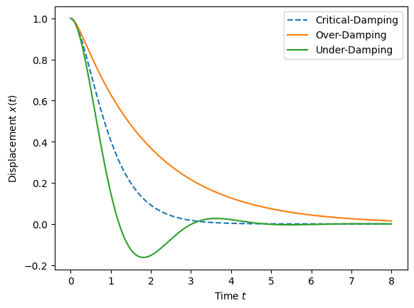

```python
import matplotlib.pyplot as plt
import numpy as np


def x_analytic(x0,v0,t0,tMax, m,k,beta):

        t = np.arange(t0,tMax,0.001)

        if beta > np.sqrt(4*m*k):

            # over damping
            r1 = (-beta+np.sqrt(beta**2 - 4*m*k))/(2*m)
            r2 = (-beta-np.sqrt(beta**2 - 4*m*k))/(2*m)
            x = (x0*r2-v0)/(r2-r1)*np.exp(r1*t) + \
                (v0-x0*r1)/(r2-r1)*np.exp(r2*t)

        if beta == np.sqrt(4*m*k):

            # critical damping
            r = -beta/(2*m)
            x = x0*np.exp(r*t) + (v0+beta/(2*m)*x0)*t*np.exp(r*t)


        if beta < np.sqrt(4*m*k):

            # under damping
            omega = np.sqrt(4*m*k-beta**2)/(2*m)
            r = -beta/(2*m)
            x = (x0*np.cos(omega*t) + \
                 1/omega*(v0 + beta/(2*m)*x0)*np.sin(omega*t))*np.exp(r*t)

        return t, x

t, x_over  = x_analytic(1,0,0,8, 1,4,8)
t, x_crit  = x_analytic(1,0,0,8, 1,4,4)
t, x_under = x_analytic(1,0,0,8, 1,4,2)

plt.plot(t,x_crit,'--',label='Critical-Damping')
plt.plot(t,x_over,label='Over-Damping')
plt.plot(t,x_under,label='Under-Damping')
plt.xlabel('Time $t$')
plt.ylabel('Displacement $x(t)$')
plt.legend()
plt.show()
```

## การคำนวณเชิงตัวเลข ด้วย Euler-Cromer Method

การคำนวณเชิงตัวเลข เป็นวิธีที่นิยมใช้กันมาก หากเราเลือกวิธีที่ให้ความแม่นยำพอใช้ได้ วิธีที่นำเสนอนี้เรียกว่า Euler-Cromer โดยทำการอัพเดทความเร็วและพิกัด ดังแผนภาพต่อไปนี้

$$ \begin{equation} \begin{aligned} & \text{at time } t_i: & \quad & x_i, \; v_i, \; a_i = \frac{\sum F(x_i,v_i)}{m} \\ & \text{at time } t_{i+1}: & \quad & v_{i+1} = v_i + a_i \Delta t \\ & & \quad & x_{i+1} = x_{i} + v_{i+1} \Delta t \end{aligned} \end{equation} $$

จะเห็นว่าผลลัพธ์การคำนวณ สอดคล้องกันเป็นอย่างดี กับวิธีวิเคราะห์ด้วยการแก้สมการออกมาโดยตรง

วิธีเชิงคำนวณ (Numerical) ลักษณะนี้ใช้งานได้ง่าย เพราะไม่จำเป็นต้องแก้สมการใดทั้งสิ้น อีกทั้งยังใข้ได้ทั่วไกับแรงแบบใดก็ได้ เพียงแต่กำหนด $\sum F$ ที่แตกต่างออกไปตามที่ต้องการ และคงส่วนอื่นของโค้ดไว้คงเดิม

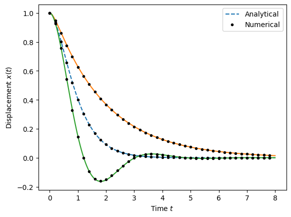

```python
def euler_cromer(x0,v0,t0,tMax, m,k,beta):

    dt = 0.01
    t = np.arange(t0,tMax,dt)
    x = np.zeros(len(t))
    v = np.zeros(len(t))
    a = np.zeros(len(t))
    x[0] = x0
    v[0] = v0

    for i in range(0,len(t)-1):
        a[i] = (-k*x[i]-beta*v[i])/m
        v[i+1] = v[i] + a[i]*dt
        x[i+1] = x[i] + v[i+1]*dt

    return t, x

tn,xn_over  = euler_cromer(1,0,0,8, 1,4,8)
tn,xn_crit  = euler_cromer(1,0,0,8, 1,4,4)
tn,xn_under = euler_cromer(1,0,0,8, 1,4,2)

plt.plot(t,x_crit,'--',label='Analytical')
plt.plot(t,x_over)
plt.plot(t,x_under)

skip=int(float(len(tn))/40)
plt.plot(tn,xn_crit,'k.',markevery=skip,label='Numerical')
plt.plot(tn,xn_over,'k.',markevery=skip)
plt.plot(tn,xn_under,'k.',markevery=skip)

plt.legend()
plt.xlabel('Time $t$')
plt.ylabel('Displacement $x(t)$')
plt.show()
```